# LTI Discrete-Time Systems: Response Modes

Table of Contents

Introduction The Response Modes First Scenario: No Null Eigenvalues Second Scenario: At Least One Null Eigenvalue References Before You Start Computation of the Response Mode Matrices Using MATLAB Special Case: All Eigenvalues Are Distinct Using the Z-transform Response Modes Computation Exploiting Left & Right Eigenvectors General Case: Multiple Eigenvalues Is the Matrix Diagonalisable? Evaluating the Algebraic Multiplicity of the Distinct Eigenvalues Evaluating the Geometric Multiplicity of the Distinct Eigenvalues Algebraic & Geometric Multiplicity of Eigenvalues vs Diagonal Form Computing the Response Modes The Response Mode Associated to the Null Eigenvalue The Response Modes Associated to the Multiple Eigenvalue The Matrix Power Summary

## Introduction

In the case of a linear, time-invariant, discrete dynamical system,

$\left \{ \begin{array}{rcl} x(k+1) &=& A x(k)+ B u(k) \, , \quad x(0) = x_0 \\ y(k) &=& C x(k) + D u(k) \end{array} \right .$

the state movement takes the form

$\begin{array}{lcl} x(k)&=& \displaystyle A^{k} x_0 + \sum_{j=0}^{k-1} A^{k-(j+1)} B \,u(j) \, , \quad k > 0 \end{array}$

Then, the output movement is

$\begin{array}{lcl} y(k)&=& \displaystyle C A^{k} x_0 + \sum_{j=0}^{k-1} C A^{k-(j+1)} B \,u(j) +D \,u(k) \, , \quad k > 0 \end{array}$

In both expressions, the matrix term $A^{k}$ appears. It is possible to evaluate $A^{k}$ by highlighting the contribution of each distinct eigenvalue of the matrixA, employing so-called response modes (a sort of "matrix partial fraction expansion ").

### The Response Modes

Let $\lambda_1, \ldots, \lambda_{\sigma}$ denote the σ distinct eigenvalues of the matrix A, and $n_i \quad (i=1\,,\;2\,,\; \ldots \sigma)$ is the algebraic multiplicity of such eigenvalues - of course $\sum_{i=1}^\sigma n_i = n$, where nis the degree of the matrix characteristic polynomial $p_{A}\left(\lambda\right) = \det \left( \lambda \,I-A \right)$ .

Consider the following two cases:

1. There is no null eigenvalue;
2. At least one eigenvalue is zero.

#### First Scenario: No Null Eigenvalues

The following expression applies in this case

$A^k = \sum_{i=1}^\sigma \left [ A_{i 0} \cdot\lambda_i^k \cdot1(k) + \sum_{l=1}^{n_i-1} A_{i l}\cdot k \cdot(k-1) \cdots (k-l+1) \cdot \lambda_i^{k-l} \cdot 1(k-l) \right ]$ (1)

where the matrices

$A_{i l} =\frac{1}{l!} \frac{1}{(n_i-1-l)!} \lim_{z \to \lambda_i} \left \{ \frac{d^{n_i-1-l}}{d z^{n_i-1-l}} \left [(z-\lambda_i)^{n_i} (zI-A)^{-1} \right ] \right \} \quad n_i \ge 1\,,\; l=0\,,\;1\,,\;\ldots n_i-1$ (2)

are the response modes.

When all eigenvalues of A are distinct, i.e. $\sigma = n; \, n_i =1, i=1,\ldots,n$, then

$A^k = \sum_{i=1}^n A_{i} \lambda_i^k \qquad A_{i} = \lim_{z \to \lambda_i} \left [(z-\lambda_i) (zI-A)^{-1} \right ] \; i = 1\,,\;2\,,\; \ldots n$ (3)

In the special case of distinct eigenvalues of A, a different characterisation of the response mode matrices exists

$A_i = v_i \cdot \tilde v_i^{\top}$ (4)

where

- $(\lambda_i I - A) \cdot v_i = 0$ : $v_i$ right eigenvector associated with $\lambda_i$;
- $\tilde v_i^{\top}\cdot (\lambda_i I - A) = 0$: $\tilde v_i^{\top}$ left eigenvector associated with $\lambda_i$ .

#### Second Scenario: At Least One Null Eigenvalue

If an eigenvalue $\lambda_j$ of A is zero, then the terms in the expression of $A^k$, corresponding to the zero eigenvalue must be computed as follows

$A_{j 0} \cdot \delta(k) + \sum_{l=1}^{n_j-1} A_{j l}\, l! \, \delta(k-l)$ (5)

where

$A_{j l} =\frac{1}{l!} \frac{1}{(n_j-1-l)!} \lim_{z \to 0} \left \{ \frac{d^{n_j-1-l}}{d z^{n_j-1-l}} \left [z^{n_j} (zI-A)^{-1} \right ] \right \} \quad n_j \ge 1\,,\; l=0\,,\;1\,,\;\ldots n_j-1$ (6)

### References

For details on the response modes, how to derive the formulas in this live script and for further examples, please refer to:

Antsaklis, P. J., Michel A. N. , Linear systems, Birkhäuser Boston, 2006.

available also as [e-book](https://www.biblio.units.it/SebinaOpac/resource/linear-systems/TSA1447982?locale=eng&tabDoc=tabcata) in the University Library.

## Before You Start

Work your way through the sections of this live scripts, using the links to navigate through the various addressed topics. You can also browse the live script as PDF or HTML document. Please pay attention: the PDF and the HTML version of a live script do not preserve the capability of inserting a MATLAB command or a piece of code directly in the live script, obtaining the result directly in the script itself.

What you will learn:

- How to compute the response mode matrices using MATLAB, in both the scenarios depicted above;
- How to proficiently solve either symbolic and numeric problems, involving the computation of the response modes using MATLAB.

```matlab
clear
close all
clc
sympref('HeavisideAtOrigin',1); % initial setting
```

## Computation of the Response Mode Matrices Using MATLAB

### Special Case: All Eigenvalues Are Distinct

Consider the LTI discrete-time autonomous system

$x(k+1) = A\, x(k)$

where

$A = \left[ \begin{array}{ccc} 1 & 0 & 0 \\ 0 & 0.5 & 1 \\ -1 & 0 & 3 \end{array} \right]$

Let us compute the response mode matrices associated with the matrix power $A^k$. Moreover, given a generic state

$x_0 = \left[ \begin{array}{c} \alpha \\ \beta \\ \gamma \end{array} \right] \quad \alpha\,,\; \beta\, , \; \gamma \in \mathbb{R}$

compute the free state movement, starting from the initial state $x(0) = x_0$.

```matlab
syms alpha beta gamma % the three parameters, used to define the generic initial state
x0 = [alpha; beta; gamma] % the initial state
```

x0 =

```matlab
A = sym([1, 0, 0; 0, 1/2, 1;-1, 0, 3]) % assigning the matrix A as symbolic object
```

A =

First check: does matrixA admit diagonal form?

```matlab
[eigVects, lambdaSET] = eig(A)
```

eigVects =

lambdaSET =

```matlab
% extracting the main diagonal from the square matrix lambdaSET, creating
% a column vector and assigning the col. vector to lambdaSET
lambdaSET = diag(lambdaSET)
```

lambdaSET =

How many distinct eigenvalues?

```matlab
numel(unique(lambdaSET))
```

ans = 3

How many independent eigenvectors correspond to each distinct eigenvalue?

```matlab
rank(eigVects)
```

ans = 3

The algebraic and the geometric multiplicity of each eigenvalue are equal each other and equal to one. So the matrix A does admit diagonal form.

Now we have two alternatives:

- to compute the response modes using the Z-transform, according to Eq. (3);
- to use the alternative characterisation, based on right and left eigenvectors, as reported in Eq. (4).

#### Using the Z-transform

```matlab
lambda1 = lambdaSET(1);
lambda2 = lambdaSET(2);
lambda3 = lambdaSET(3);

syms z n
zIA = z*eye(size(A))-A;
zIA_inv = inv(zIA);
```

First response mode, according to Eq. (3)

```matlab
% evaluation of a limit using the symbolic toolbox
A_1 = limit((z-lambda1)*zIA_inv,z, lambda1 ) %#ok<*MINV> % code suppressing warning message
```

A_1 =

The contribution $A_1\, \lambda_1^k$ is

```matlab
A_1*lambda1^n
```

ans =

The second response mode matrix and the corresponding contribution to the matrix power $A^k$ are

```matlab
A_2 = limit((z-lambda2)*zIA_inv,z, lambda2 )
```

A_2 =

```matlab
A_2*lambda2^n
```

ans =

Finally, the third response mode and its contribution to $A^k$ are

```matlab
A_3 = limit((z-lambda3)*zIA_inv,z, lambda3 )
```

A_3 =

```matlab
A_3*lambda3^n
```

ans =

Now we can write down the matrix power $A^k$ as sum of the response mode contriibutions, as follows

```matlab
Ak = A_1 * lambda1^n + A_2*lambda2^n+A_3*lambda3^n
```

Ak =

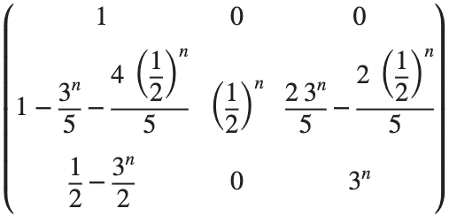

Let us compare with the matrix power obtained directly applying the inverse Z-transform

```matlab
ApowZ = z*zIA_inv;
Apow = iztrans(ApowZ)
```

Apow =

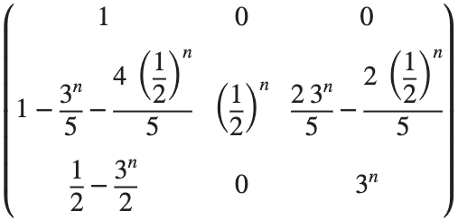

Let us compare the two resulting $A^k$ expressions

```matlab
isequaln(Ak, Apow)
```

ans = logical 1

The Free State Movement

At this point, we can evaluate the expression of the free state movement, starting from the given (symbolic) initial state

```matlab
freeMov_x = Apow * x0
```

freeMov_x =

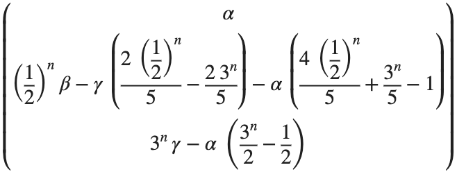

#### Response Modes Computation Exploiting Left & Right Eigenvectors

Let us consider the same LTI system and determine the response modes using left and right eigenvectors, according to Eq. (4).

Let's start with the right eigenvectors.

```matlab
[rV, ~] = eig(A); % the right eigenvectors

% let's verify: rV columns are the right eigenvectors iff
syms res [3 3]
for c = 1:3
    res(:,c) = A*rV(:,c) - lambdaSET(c)*rV(:,c);
end
disp(res)
```

Now the left eigenvectors:

the following property holds true

$\tilde v_i^{\top}(\lambda_i I - A) = 0 \quad \Longrightarrow \quad \left[ \tilde v_i^{\top}(\lambda_i I - A) \right]^{\top} = 0 \quad \Longrightarrow \quad \left(\lambda_i I - A^{\top}) \tilde v_i = 0$

```matlab
% the left eigenvectors of A are the right eigenvectors of the transpose
% matrix A'

[lV, ~] = eig(A');
lV = lV'; % the right eigenvectors are row vectors
```

```matlab
syms resL [3 3]
for r = 1:3
    resL(r,:) = lV(r,:)*A - lambdaSET(r)*lV(r,:);
end
disp(res)
```

Let's check the orthonormality

$\tilde v_i^{\top} v_j = \left \{ \begin{array}{ll} 1 \, \, & i=j \\ 0 & i \not= j \end{array}$

and, in case, adjust the norm of the left (or right) eigenvectors

```matlab
shouldBeEyematrix = lV*rV
```

shouldBeEyematrix =

```matlab
diagElm = diag(shouldBeEyematrix); % extract the main diagonal as a vector
shouldBeNullMatrix = shouldBeEyematrix- diag(diagElm); % subtract the main diagonal

% check: if shouldBeNullMatrix is not a null matrix, then through an error
% and stop the execution of the code
assert(isequal(shouldBeNullMatrix, ...
        sym(zeros(size(shouldBeNullMatrix)))));
% please note: shouldBeNullMatrix is a symbolic matrix, so also the null
%              matrix has to be a symbolic variable (otherwise, the
%              comparison fails! Remove the symbolic casting command
%              sym().. and see the error message! In fact, in that case you would
%              compare a symbolic variable with a NOT symbolic one, so the
%              comparison fails.

if ~isequal(diagElm, ones(size(diagElm)))
    for r=1:3
        lV(r,:) = lV(r,:)/diagElm(r);
    end % for r
end
% let us check one more time
lV*rV
```

ans =

```matlab
lV
```

lV =

Remark

According to

$Q:= [v_1 \, | \, v_2 \, | \cdots | \, v_n] \, \Longrightarrow \, P = Q^{-1} = \left [ \begin{array}{c} \tilde v_1^{\top} \\ \vdots \\ \tilde v_n^{\top} \end{array} \right ] ; \, \tilde v_i^{\top} v_j = \left \{ \begin{array}{ll} 1 \, \, & i=j \\ 0 & i \not= j \end{array} \right .$

(please, refer to the class material, L3-p19), a more effiicient and quick way to obtain the left eigenvectors $\tilde v_i^{\top}$ as orthonormal vectors with respect to the right eigenvectors $v_j$ is simply

```matlab
lV_alt = inv(rV)
```

lV_alt =

Finally, we can compute the response mode matrices, by simply evaluating

```matlab
A1_alt = rV(:,1)*lV(1,:) %#ok<*NASGU>
```

A1_alt =

```matlab
A2_alt = rV(:,2)*lV(2,:)
```

A2_alt =

```matlab
A3_alt = rV(:,3)*lV(3,:)
```

A3_alt =

As you can easily check by comparison, the response modes A1, A2, and A3 are equal respectively to A1_alt, A2_alt, and A3_alt.

## General Case: Multiple Eigenvalues

Consider the LTI discrete-time autonomous system

$x(k+1) = A\, x(k)$

where

Let us compute the response mode matrices associated with the matrix power $A^k$. Moreover, given a generic state

$x_0 = \left[ \begin{array}{c} \alpha \\ \beta \\ \gamma \\ \delta \end{array} \right] \quad \alpha\,,\; \beta\, , \; \gamma\, , \; \delta \in \mathbb{R}$

compute the free state movement, starting from the initial state $x(0) = x_0$.

```matlab
clear
clc
syms alpha beta gamma delta  % the parameters, used to define
                             % the generic initial state
x0 = [alpha; beta; gamma; delta] % the initial state
```

x0 =

```matlab
A = sym([3, -1, 1, 1 ;...
         1, 1, -1, -1;...
         0, 0, 2, 0; ...
         0, 0, 0, 0])
```

A =

### Is the Matrix Diagonalisable?

First check: does matrixA admit diagonal form?

```matlab
[eigVects, lambdaSET, p] = eig(A);
% extracting the main diagonal from the square matrix lambdaSET, creating
% a column vector and assigning the col. vector to lambdaSET
lambdaSET = diag(lambdaSET)
```

lambdaSET =

What is the vector p?

Please, refer to the MATLAB help

help symbolic/eig

and refer also to this section of the current document, for a practical use of the vector p.

How many distinct eigenvalues?

```matlab
lambdaU = unique(lambdaSET);
numel(lambdaU)
```

ans = 2

#### Evaluating the Algebraic Multiplicity of the Distinct Eigenvalues

What about the algebraic multiplicity?

```matlab
algMult = zeros(numel(lambdaU),1); % preallocate an array
for j=1:numel(lambdaU)
    algMult(j) = sum(double(lambdaSET)==double(lambdaU(j)));
end % for j
disp(lambdaU)
```

```matlab
disp(algMult)
```

1 3

Summarising, we have only two distinct eigenvalues:

- the first distinct eigenvalue $\lambda_1 = 0$ has algebraic multiplicity equal to 1;
- the second distinct eigenvalue $\lambda_2 = 2$ has algebraic multiplicity equal to 3.

#### Evaluating the Geometric Multiplicity of the Distinct Eigenvalues

What about the geometric multiplicity? How to use the vector p?

```matlab
disp(eigVects)
```

```matlab
disp(lambdaSET)
```

```matlab
disp(p)
```

1 2

The vector of indices p shows that:

- p(1) = 1, so the first eigenvector (the first column of eigVects) corresponds to the first element of lambdaSET, with eigenvalue $\lambda_1 = 0$;
- p(2) = 2, so the second eigenvector (the second column of eigVects) corresponds to the second element of lambdaSET with eigenvalue $\lambda_2 = 2$.

#### Algebraic & Geometric Multiplicity of Eigenvalues vs Diagonal Form

The findings about the algebraic and geometric multiplicity of the eigenvalues allow us to state:

- The eigenvalue $\lambda_1 = 0$, that occurs once, has one linearly independent eigenvector (the eigenvalue $\lambda_1$has algebraic multiplicity 1 and geometric multiplicity 1).
- The eigenvalue $\lambda_2 = 2$, that occurs three times, has one linearly independent eigenvectors (the eigenvalue $\lambda_2 = 2$ has algebraic multiplicity 3 and geometric multiplicity 1).

The matrix A does not admit a diagonal form (indeed, the matrix admits a Jordan canonical form). Moreover, there is a null eigenvalue. So, to determine the expression of the response mode matrices, we have to rely on the Eq. (2) and Eq. (6).

### Computing the Response Modes

```matlab
syms z n
zIA = z*eye(size(A))-A;
zIA_inv = inv(zIA);
```

#### The Response Mode Associated to the Null Eigenvalue

Associated to the eigenvalue $\lambda_1 = 0$, the response mode $A_1$ can be computed as follows (according to Eq. (6))

$A_{1 0} =\displaystyle \lim_{z \to 0} \left [z \cdot (zI-A)^{-1} \right ]$

```matlab
A_10 = limit(z*zIA_inv,z, lambdaU(1) )
```

A_10 =

The contribution to the matrix power $A^k$ is (according to Eq. (5) )

```matlab
A_10 * kroneckerDelta(n)
```

ans =

#### The Response Modes Associated to the Multiple Eigenvalue

According to Eq. (2), associated to the eigenvalue $\lambda_2 = 2$ we have 3 different response mode matrices

$A_{2 0 } =\frac{1}{0!} \frac{1}{(3-1)!} \lim_{z \to 2} \left \{ \frac{d^{3-1}}{d z^{3-1}} \left [(z-2)^{3} (zI-A)^{-1} \right ] \right \} = \frac{1}{2!} \lim_{z \to 2} \left \{ \frac{d^{2}}{d z^{2}} \left [(z-2)^{3} (zI-A)^{-1} \right ] \right \}$

```matlab
D0 = (((z-lambdaU(2))^3) * zIA_inv);
D1 = diff( D0, z, 1);
D2 = diff( D1, z, 1);
% D2 = diff( (((z-lambdaU(2))^3) * zIA_inv), z, 2);
A_20 = limit( D2 , z, lambdaU(2) )/ factorial(2)
```

A_20 =

The contribution to the matrix power $A^k$ is (according to Eq. (1) )

```matlab
A_20*(lambdaU(2)^(n))
```

ans =

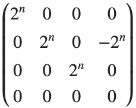

$A_{2 1 } =\frac{1}{1!} \frac{1}{(3-2)!} \lim_{z \to 2} \left \{ \frac{d^{3-2}}{d z^{3-2}} \left [(z-2)^{3} (zI-A)^{-1} \right ] \right \} = \frac{1}{1!} \lim_{z \to 2} \left \{ \frac{d }{d } \left [(z-2)^{3} (zI-A)^{-1} \right ] \right \}$

```matlab
A_21 = limit( D1 , z, lambdaU(2) )/ factorial(1)
```

A_21 =

The contribution to the matrix power $A^k$ is (according to Eq. (1) )

```matlab
simplify(A_21*(nchoosek(n, 1)*(lambdaU(2)^(n-1)))*factorial(1))
```

ans =

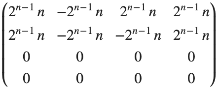

$A_{2 2 } =\frac{1}{2!} \frac{1}{(3-3)!} \lim_{z \to 2} \left \{ \frac{d^{3-3}}{d z^{3-3}} \left [(z-2)^{3} (zI-A)^{-1} \right ] \right \} =\frac{1}{2!} \lim_{z \to 2} \big [(z-2)^{3} (zI-A)^{-1} \big ]$

```matlab
A_22 = limit( D0 , z, lambdaU(2) )/ (factorial(2))
```

A_22 =

The contribution to the matrix power $A^k$ is (according to Eq. (1) )

```matlab
simplify(A_22*(nchoosek(n, 2)*(lambdaU(2)^(n-2)))*factorial(2))
```

ans =

#### The Matrix Power

Finally, the matrix power $A^k$ is

```matlab
Ak = simplify(...
     ( A_10 * kroneckerDelta(n) ) + ...
     ( A_20 * (lambdaU(2)^n ) )   + ...
     ( A_21 * (lambdaU(2)^(n-1) ) * nchoosek(n,1) *factorial(1) ) + ...
     ( A_22 * (lambdaU(2)^(n-2) ) * nchoosek(n,2) *factorial(2) ))
```

Ak =

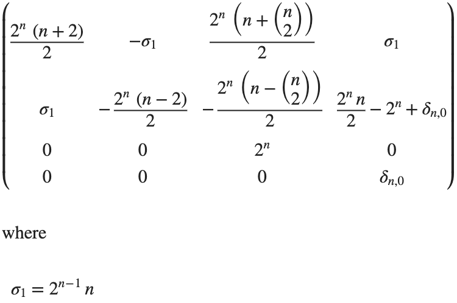

Alternative way: using the Z-transform to compute directly $A^k$

```matlab
Ak_alt = simplify(iztrans(z*zIA_inv))
```

Ak_alt =

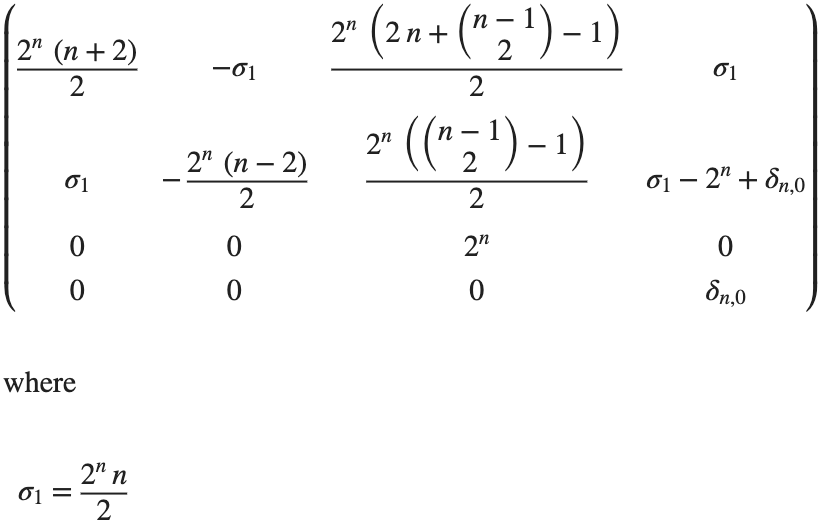

Are the two expressions equal?

```matlab
simplify(expand(Ak-Ak_alt))
```

ans =

```matlab
simplify(ztrans(Ak)-ztrans(Ak_alt))
```

ans =

Yes, they are describing the same matrix power $A^k$.

## Summary

Using this live script you learnt:

- How to compute the response mode matrices using MATLAB, either in the case of all distinct eigenvalues, either when multiple eigenvalues exist;
- How to proficiently solve either symbolic and numeric problems, involving the computation of the response modes using MATLAB.